# Final EDA Project

Richy Varghese

February 19, 2019

### GITHUB LINK: https://github.com/richyvarghese/ANLY506_RichyVarghese_FinalProject

### Packages

```r
#Loading packages
library("dplyr")
library("ggplot2")
library("RColorBrewer")
library("tidyverse")
library("cluster")
library("factoextra")
library("dendextend")
```

### Data

```r
#Importing data
gapminder <- read.csv("C:/Users/Richy/Desktop/Harrisburg University/Exploratory Data Analytics/FinalProject/ANLY506_RichyVarghese_FinalProject/Data/Data_EDAAssignment/gapminder.csv", header = TRUE)
```

### Data Exploration and Cleaning

```r
#Checking the data structure
str(gapminder)
```

```
## 'data.frame':    41284 obs. of  6 variables:
##  $ Country   : Factor w/ 197 levels "Ãland","Afghanistan",..: 2 2 2 2 2 2 2 2 2 2 ...
##  $ Year      : int  1800 1801 1802 1803 1804 1805 1806 1807 1808 1809 ...
##  $ life      : num  28.2 28.2 28.2 28.2 28.2 ...
##  $ population: Factor w/ 15260 levels "","1,005,328,574",..: 7490 1 1 1 1 1 1 1 1 1 ...
##  $ income    : num  603 603 603 603 603 603 603 603 603 603 ...
##  $ region    : Factor w/ 6 levels "America","East Asia & Pacific",..: 5 5 5 5 5 5 5 5 5 5 ...
```

```r
#Country and Region should be factors, while Life, Population, Year and Income should be numerics hence converting the data to the right data types
gapminder$Year <- factor(gapminder$Year)
gapminder$population <- as.numeric(as.character(gapminder$population))
gapminder$Year <- as.numeric(as.character(gapminder$Year))
str(gapminder)
```

```
## 'data.frame':    41284 obs. of  6 variables:
##  $ Country   : Factor w/ 197 levels "Ãland","Afghanistan",..: 2 2 2 2 2 2 2 2 2 2 ...
##  $ Year      : num  1800 1801 1802 1803 1804 ...
##  $ life      : num  28.2 28.2 28.2 28.2 28.2 ...
##  $ population: num  3280000 NA NA NA NA NA NA NA NA NA ...
##  $ income    : num  603 603 603 603 603 603 603 603 603 603 ...
##  $ region    : Factor w/ 6 levels "America","East Asia & Pacific",..: 5 5 5 5 5 5 5 5 5 5 ...
```

```r
#Now, all data types seem to be correct
#Looking at the top and bottom few rows of the dataset
head(gapminder)
```

```
##       Country Year     life population income     region
## 1 Afghanistan 1800 28.21100    3280000    603 South Asia
## 2 Afghanistan 1801 28.20075         NA    603 South Asia
## 3 Afghanistan 1802 28.19051         NA    603 South Asia
## 4 Afghanistan 1803 28.18026         NA    603 South Asia
## 5 Afghanistan 1804 28.17001         NA    603 South Asia
## 6 Afghanistan 1805 28.15977         NA    603 South Asia
```

```r
tail(gapminder)
```

```
##       Country Year  life population income                region
## 41279  Ãland 1992 80.83      24834     NA Europe & Central Asia
## 41280  Ãland 1993 81.80      24950     NA Europe & Central Asia
## 41281  Ãland 1994 80.63      25066     NA Europe & Central Asia
## 41282  Ãland 1995 79.88      25183     NA Europe & Central Asia
## 41283  Ãland 1996 80.00      25301     NA Europe & Central Asia
## 41284  Ãland 1997 80.10      25419     NA Europe & Central Asia
```

```r
#There are NAs in population and income columns, hence checking count of NAs in every column
colSums(is.na(gapminder))
```

```
##    Country       Year       life population     income     region
##          0          0          0      27286       2341          0
```

```r
#On further exploring the data, using Excel, there seems to be missing data before 1950s, hence taking a subset of data from 1950 to 2015 for all countries
gapminder_new <- gapminder %>% filter(Year >= 1950)
#Looking at NAs in every column, the data looks much better
colSums(is.na(gapminder_new))
```

```
##    Country       Year       life population     income     region
##          0          0          0       1395        671          0
```

```r
#Remove NAs from the new data set
gapminder_new <- na.omit(gapminder_new)
#Getting the descriptive summary of the dataset
summary(gapminder_new)
```

```
##                 Country           Year           life
##  Spain              :   66   Min.   :1950   Min.   :15.60
##  Trinidad and Tobago:   66   1st Qu.:1965   1st Qu.:54.90
##  Botswana           :   65   Median :1982   Median :64.00
##  Chad               :   65   Mean   :1982   Mean   :62.46
##  Cyprus             :   65   3rd Qu.:1998   3rd Qu.:70.90
##  Kenya              :   65   Max.   :2015   Max.   :84.10
##  (Other)            :10201
##    population            income                              region
##  Min.   :2.040e+04   Min.   :   142   America                   :1903
##  1st Qu.:9.878e+05   1st Qu.:  1934   East Asia & Pacific       :1504
##  Median :4.253e+06   Median :  4680   Europe & Central Asia     :2535
##  Mean   :1.990e+07   Mean   :  9859   Middle East & North Africa:1171
##  3rd Qu.:1.303e+07   3rd Qu.: 11302   South Asia                : 469
##  Max.   :1.311e+09   Max.   :182668   Sub-Saharan Africa        :3011
##
```

### Analysis of Life Expectancy

```r
#Focussing the analysis on life expectancy since the values around within is smaller range, while population and income varies across countries and regions
#Mean and median life expectancy for each region
mean_life <- round(mean(gapminder_new$life), digits=3)
median_life <- round(median(gapminder_new$life), digits=3)
table1 <- gapminder_new %>% group_by(region) %>% summarise(mean(life), median(life))
table1
```

```
## # A tibble: 6 x 3
##   region                     `mean(life)` `median(life)`
##   <fct>                             <dbl>          <dbl>
## 1 America                            66.9           68.7
## 2 East Asia & Pacific                63.3           63.8
## 3 Europe & Central Asia              69.6           70.2
## 4 Middle East & North Africa         65.5           68.2
## 5 South Asia                         54.8           55.2
## 6 Sub-Saharan Africa                 53.3           53.3
```

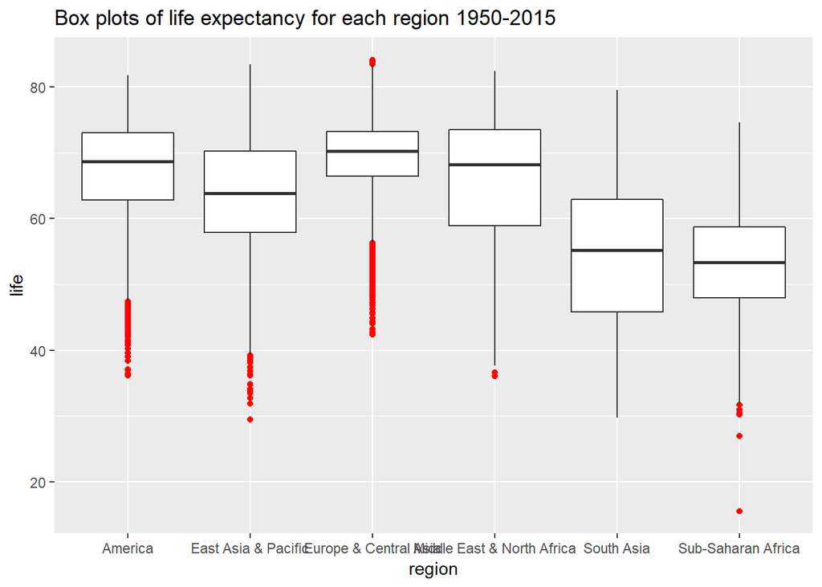

```r
#Box plots for life expectancy for each region
ggplot(gapminder_new, aes(x = region, y = life)) + geom_boxplot(outlier.colour = "red") + ggtitle("Box plots of life expectancy for each region 1950-2015")
```

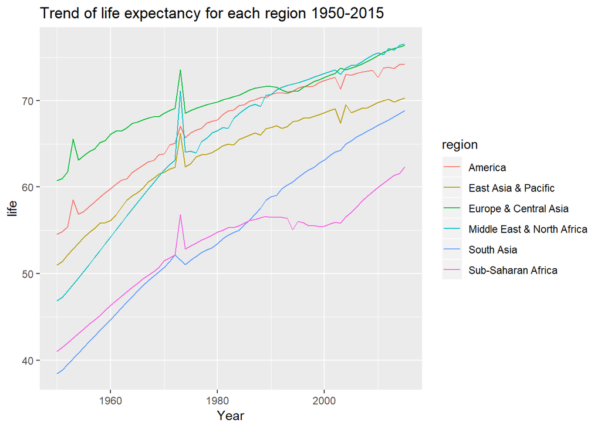

```r
#Europe and Central Asia has the highest mean and median life expectancy values
#Trend of life expectancy for each region
newdata <- aggregate(life ~ region + Year, data = gapminder_new, mean)
ggplot(newdata, aes(x = Year, y = life)) + geom_line(aes(color = region)) + ggtitle("Trend of life expectancy for each region 1950-2015")
```

```r
#Over the years, all regions seem to have an increasing life expectancy rate
```

### Life Expectancy vs Income

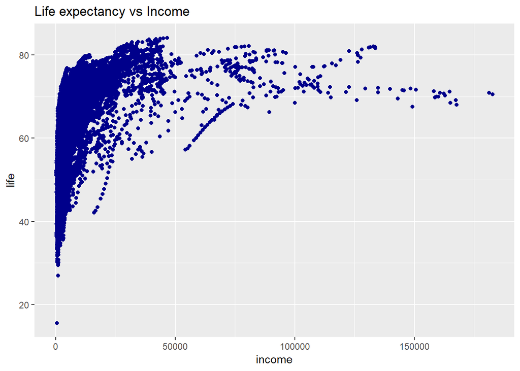

```r
ggplot(gapminder_new, aes(x = income, y = life)) + geom_point(color='darkblue') + ggtitle("Life expectancy vs Income")
```

```r
#With increasing income, life expectancy increases
```

### Population vs Life Expectancy

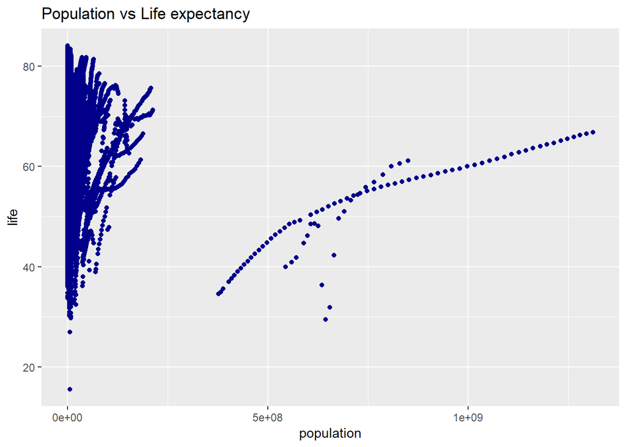

```r
ggplot(gapminder_new, aes(x = population, y = life)) + geom_point(color='darkblue') + ggtitle("Population vs Life expectancy")
```

```r
#With increasing life expectancy, population increases
```

### K-Means Clustering

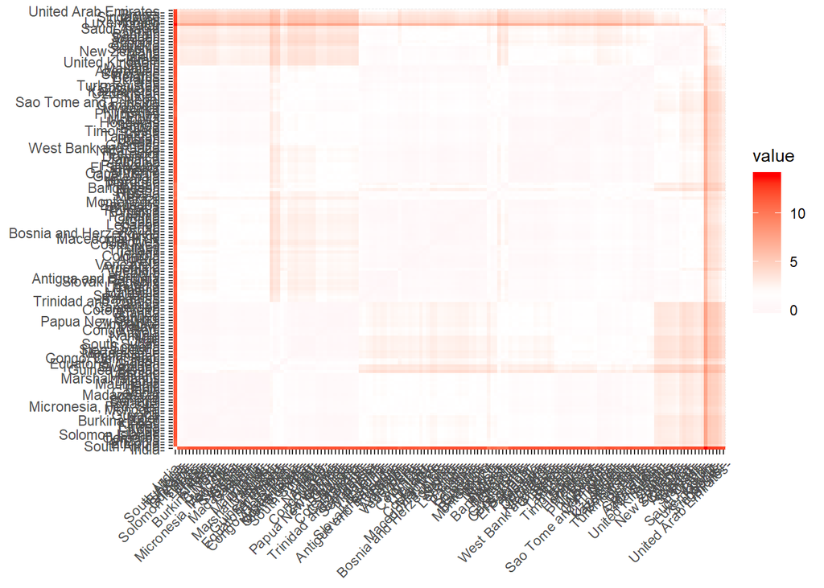

```r
#Creating a subset of the data for 2015
df <- gapminder_new %>% filter(Year == 2015) %>% select(Country, life, population, income)
row.names(df) <- df[,1]
df <- df %>% select(life, population, income)
newdf <- df
#Removing observations with NA
df <- na.omit(df)
#Scaling the dataframe
df <- scale(df)
#Creating the distance matrix
distance <- get_dist(df)
#Visualizing the distance matrix
fviz_dist(distance, gradient = list(low = "pink", mid = "white", high = "red"))
```

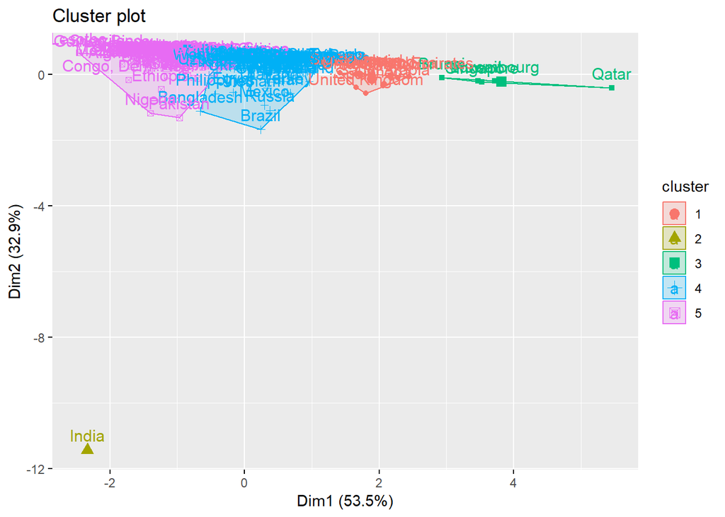

```r
#Computing the k-means
k <- kmeans(na.omit(df), centers = 5, nstart = 25)
#Visualizing the clusters
fviz_cluster(k, data = df)
```

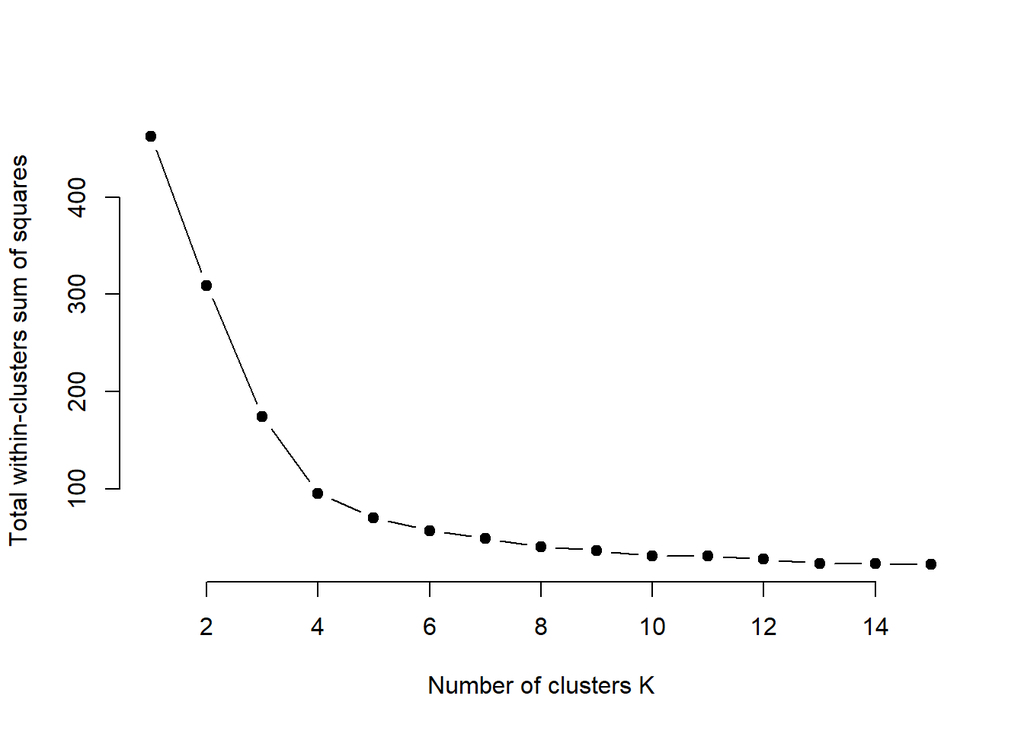

```r
#Adding cluster numbers to the data
newdf$cluster <- k$cluster

#Determining optimal clusters
#Elbow method
set.seed(123)
#Function to compute total within-cluster sum of square
wss <- function(k) {kmeans(df, k, nstart = 10 )$tot.withinss}
# Computing and plotting wss for k = 1 to k = 15
k.values <- 1:15
#Extracting wss for 2-15 clusters
wss_values <- map_dbl(k.values, wss)
plot(k.values, wss_values, type="b", pch = 19, frame = FALSE, xlab="Number of clusters K", ylab="Total within-clusters sum of squares")
```

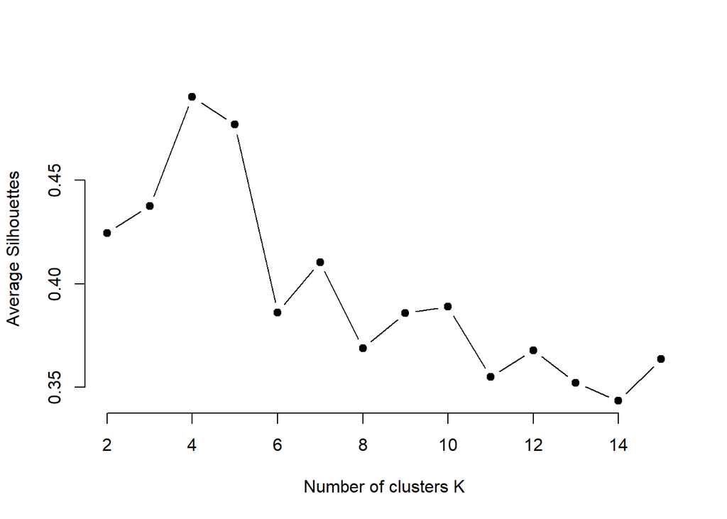

```r
#Optimal number of clusters = 4
#Average silhouette method
avg_sil <- function(k) {km.res <- kmeans(df, centers = k, nstart = 25)
                        ss <- silhouette(km.res$cluster, dist(df))
                        mean(ss[, 3])}
#Computing and plotting wss for k = 2 to k = 15
k.values <- 2:15
#Extract avg silhouette for 2-15 clusters
avg_sil_values <- map_dbl(k.values, avg_sil)
plot(k.values, avg_sil_values, type = "b", pch = 19, frame = FALSE, xlab = "Number of clusters K", ylab = "Average Silhouettes")
```

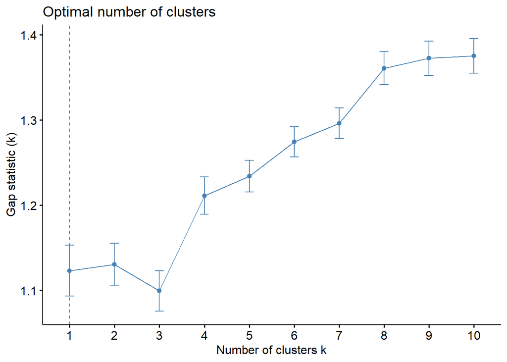

```r
#Optimal number of clusters = 4
#Gap statistic method
#Computing gap statistic
set.seed(123)
gap_stat <- clusGap(df, FUN = kmeans, nstart = 25, K.max = 10, B = 50)
fviz_gap_stat(gap_stat)
```

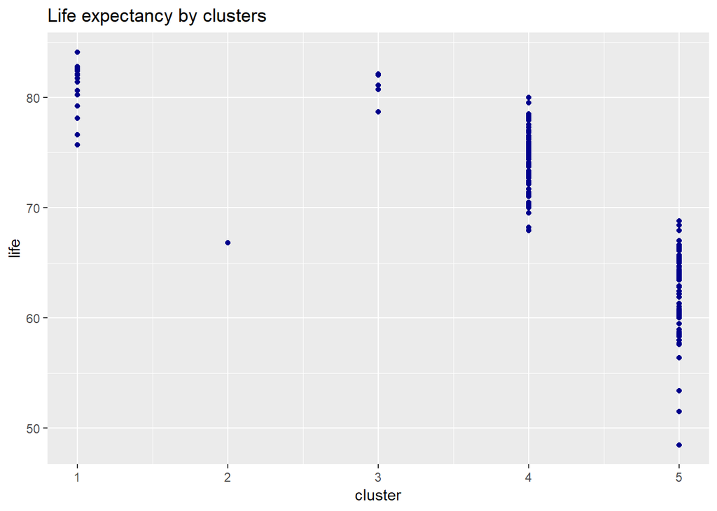

```r
#Optimal number of clusters = 1

#Visualizing life expectancy, population and income by clusters
ggplot(newdf, aes(x = cluster, y = life)) + geom_point(color='darkblue') + ggtitle("Life expectancy by clusters")
```

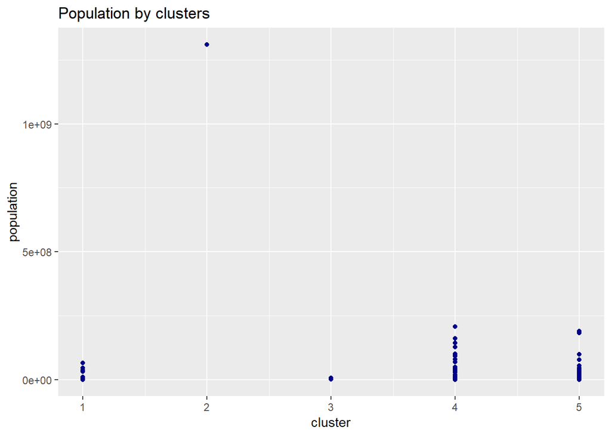

```r
ggplot(newdf, aes(x = cluster, y = population)) + geom_point(color='darkblue') + ggtitle("Population by clusters")
```

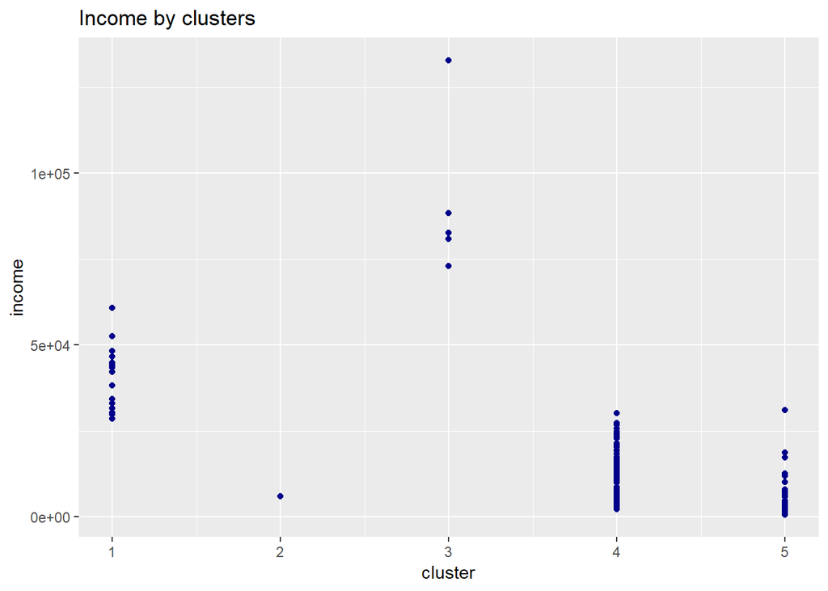

```r
ggplot(newdf, aes(x = cluster, y = income)) + geom_point(color='darkblue') + ggtitle("Income by clusters")
```

```r
table2 <- newdf %>% group_by(cluster) %>% summarise(mean(life), mean(population), mean(income))
table2
```

```
## # A tibble: 5 x 4
##   cluster `mean(life)` `mean(population)` `mean(income)`
##     <int>        <dbl>              <dbl>          <dbl>
## 1       1         80.7          14651062.         40541.
## 2       2         66.8        1311050527           5903
## 3       3         80.9           2544302.         91524.
## 4       4         74.4          24954678.         13568.
## 5       5         62.2          21885940.          4198.
```

```r
#Cluster with Kuwait, Qatar and Singapore (among others) seems to have the highest mean life expectancy, lowest mean population and highest mean income, which make countries in this cluster attractive. India has its own cluster with lower mean life expectancy, highest mean population and very low income, which forces their work force to migrate to other countries to improve their work and life standards
```

### Hierarchical Clustering

```r
#Creating a subset of the data for 2015
df <- gapminder_new %>% filter(Year == 2015) %>% select(Country, life, population, income)
row.names(df) <- df[,1]
df <- df %>% select(life, population, income)
newdf <- df
#Removing observations with NA
df <- na.omit(df)
#Scaling the dataframe
df <- scale(df)
#Getting the Euclidean distance
d <- dist(df, method = "euclidean")
#Hierarchical clustering using Complete Linkage
hc1 <- hclust(d, method = "complete" )
# Computing with agnes()
hc2 <- agnes(df, method = "ward")
#Agglomerative coefficient
hc2$ac
```

```
## [1] 0.9788506
```

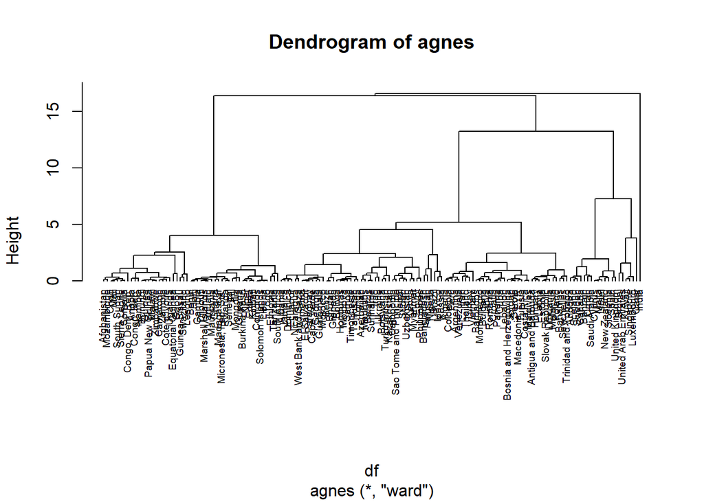

```r
#Plotting the dendrogram
pltree(hc2, cex = 0.6, hang = -1, main = "Dendrogram of agnes")
```

```r
#Divisive hierarchical clustering
#Computing divisive hierarchical clustering
hc4 <- diana(df)
#Divise coefficient
hc4$dc
```

```
## [1] 0.9735322
```

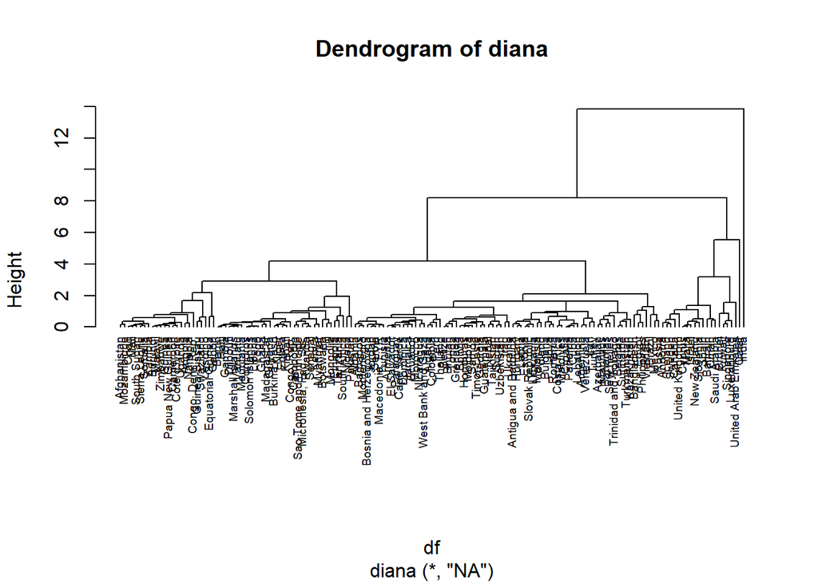

```r
#Plotting the dendrogram
pltree(hc4, cex = 0.6, hang = -1, main = "Dendrogram of diana")
```

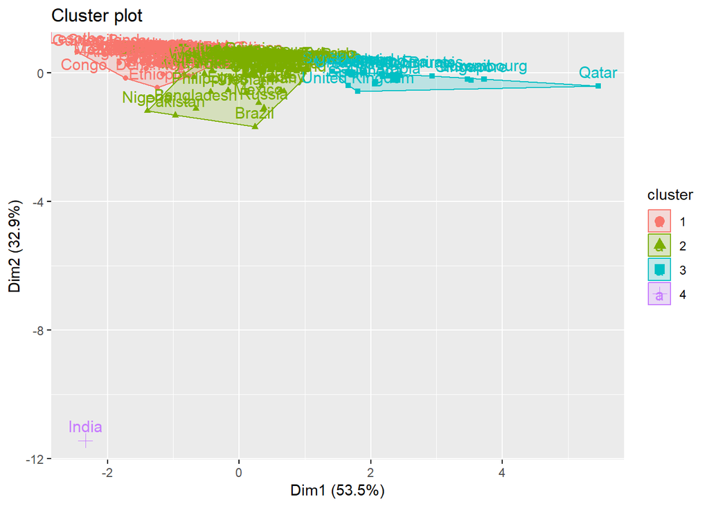

```r
#Plotting clusters but dividing the set into 4 clusters
hc5 <- hclust(d, method = "ward.D2" )
sub_grp <- cutree(hc5, k = 4)
fviz_cluster(list(data = df, cluster = sub_grp))
```

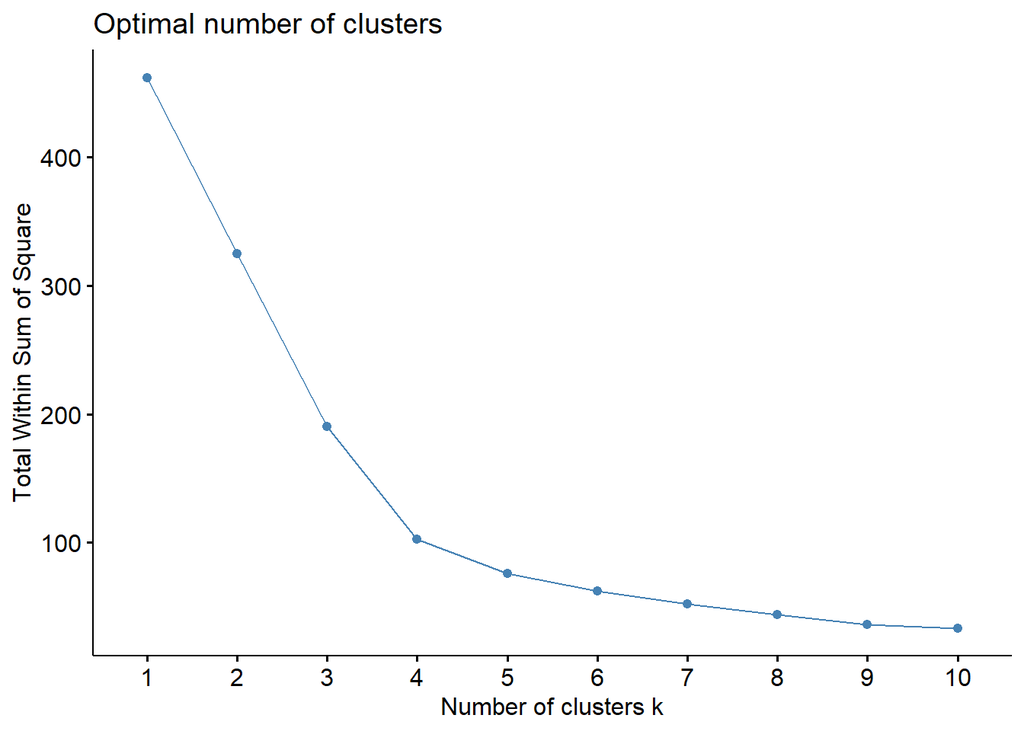

```r
#This is pretty similar to that from K-Means

#Determining optimal clusters
#Elbow method
fviz_nbclust(df, FUN = hcut, method = "wss")
```

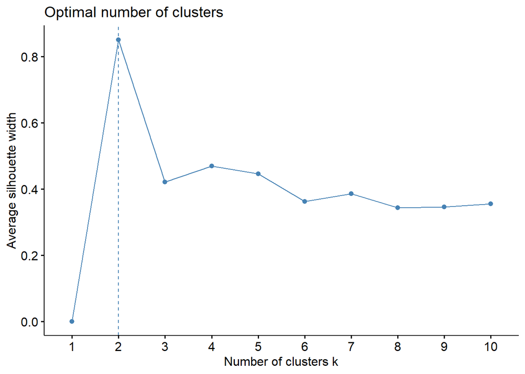

```r
#Optimal number of clusters = 4
#Average silhouette method
fviz_nbclust(df, FUN = hcut, method = "silhouette")
```

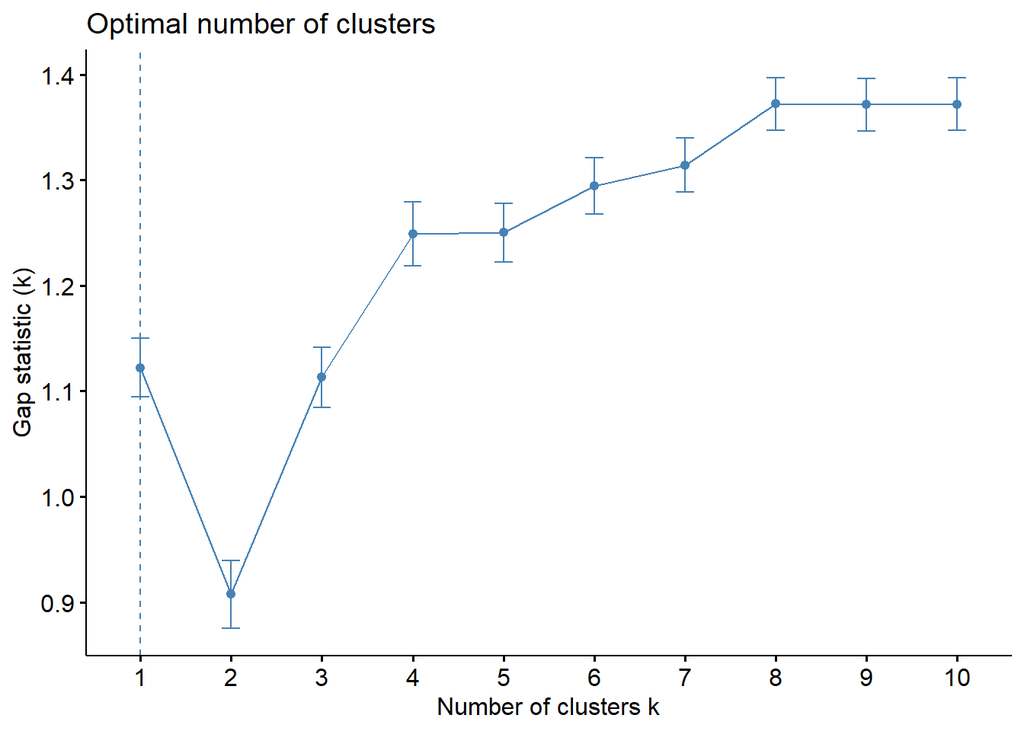

```r
#Gap statistic method
#Optimal number of clusters = 2
gap_stat <- clusGap(df, FUN = hcut, nstart = 25, K.max = 10, B = 50)
fviz_gap_stat(gap_stat)
```

```r
#Optimal number of clusters = 1
#The number of clusters generated through both hierarchical and K-means clustering were pretty identical
```

### Findings

#### 3. Is there a relationship between life expectancy and income?

##### Using K-means clustering, 4 seems to be the optimal number, while using hierarchical clustering, 2 seems to be the optimal number.

#### 6. Based on the K-means clustering output, which cluster is the best and which is the worst?

##### The cluster with Brunei, Kuwait, Luxembourg, Qatar and Singapore seems to have the highest mean life expectancy, lowest mean population and highest mean income, which make countries in this cluster attractive. Being born and raised in Kuwait, I have experienced the quality of life, higher incomes and lower mortality rates, and hence confirms this result. India has its own cluster with lower mean life expectancy, highest mean population and very low income, which forces their work force to migrate to other countries to improve their work and life standards. Being an Indian citizen by origin, and living in India for a few years, I believe this is true, as like many others I have moved to the US in search of better opportunities, standard of living, income and lower population per region (as compared to India).